# Różnice poparcia dla partii w ramach jednej gminy

Piotr Sobczyk

03.02.2015 (update 08.02.2015)

W tym raporcie analizujemy odchylenia poparcia w lokalach wyborczych w odniesieniu do poparcia w danej gminie. Pomysł jaki stoi za tym jest następujący: Powinno to być w miarę normalne, nie ma zbyt dużo powodów, żeby na terenie jednej gminy, różnice w wyobrach do sejmiku wojewódzkiego były znacząco różne.

Bierzemy tylko wyniki 4 największych partii i komisje obwodowe, z więcej niż 500 wyborcami (eliminujemy skrajnie małe lokale typu szpitale).

```r
duze.partie <- unique(dane$partia)[c(1,3,4,6)]
dane.diff <- dane %>%
  filter(wyborcy > 500,
         partia %in% duze.partie)
```

Teraz bardzo brzydkie bebechy. Fajnie by było to zrobić jakiś inny sposób. Liczymy średnie poparcie w gminach i dołączamy jet do ramki danych.

```r
a <- aggregate(dane.diff$wynik, by=list(dane.diff$kod, dane.diff$partia), FUN = median)
a2 <- aggregate(dane.diff$glosy, by=list(dane.diff$kod, dane.diff$partia), FUN = sum)
b2 <- aggregate(dane.diff$wyborcy*dane.diff$frekwencja*(1-dane.diff$niewazne/100)/100, by=list(dane.diff$kod, dane.diff$partia), FUN = sum)
b <- aggregate(dane.diff$wynik, by=list(dane.diff$kod, dane.diff$partia), FUN = length)

gmina.mediana <- NULL
for(i in 1:nrow(a)){
  gmina.mediana <- c(gmina.mediana, rep(a[i,3], b[i,3]))
}

gmina.srednia <- NULL
for(i in 1:nrow(a2)){
  gmina.srednia <- c(gmina.srednia, rep(a2[i,3]/b2[i,3], b[i,3]))
}

dane.diff <- dane.diff %>%
  arrange(partia, kod)
dane.diff <- cbind(dane.diff, gmina.srednia)
```

Teraz liczymy różnice pomiędzy średnimi w gminach, a poparciem w komisjach obwodowych. Zakładamy, że ramach jednej gminy, każdy wyborca głosuje na partię $i$ z p-stwem $p_i$. Wobec tego w $j$-tej komisji obwodowej, w której głosowało $n_j$ wyborców, liczba głosów ma rozkład dwumianowy $B(n_j\cdot p_i, n_j\cdot p_i \cdot (1-p_i))$ Ponieważ $n_j$ są duże, to możemy to przybliżyć rozkładem normalnym i ustandaryzować $\text{Poparcie partii i w komisji j} \sim B\left(p_i, \frac{p_i \cdot (1-p_i)}{n_j}\right)$ $\text{Poparcie partii i w komisji j - poparcie dla i w gminie} \sim B\left(0, \frac{p_i \cdot (1-p_i)}{n_j}\right) \approx \mathcal{N}\left(0, \frac{p_i \cdot (1-p_i)}{n_j}\right)$

```r
dane.diff <- dane.diff %>%
  mutate(diff2 = (wynik/100-gmina.srednia),
         odchylenie = sqrt(gmina.srednia*(1-gmina.srednia))/sqrt(wyborcy*frekwencja*(1-niewazne/100)/100),
         diff = diff2/odchylenie) %>%
  dplyr::select(kod, typ, wojewodztwo, frekwencja, niewazne, partia, wynik, gmina.srednia, diff2, diff, odchylenie)
```

Unormowane odchyły od średniej powinny zatem, w naszym modelu, mieć rozkład $\mathcal{N}(0,1)$. Te odchyły w podziale na partię ogółem.

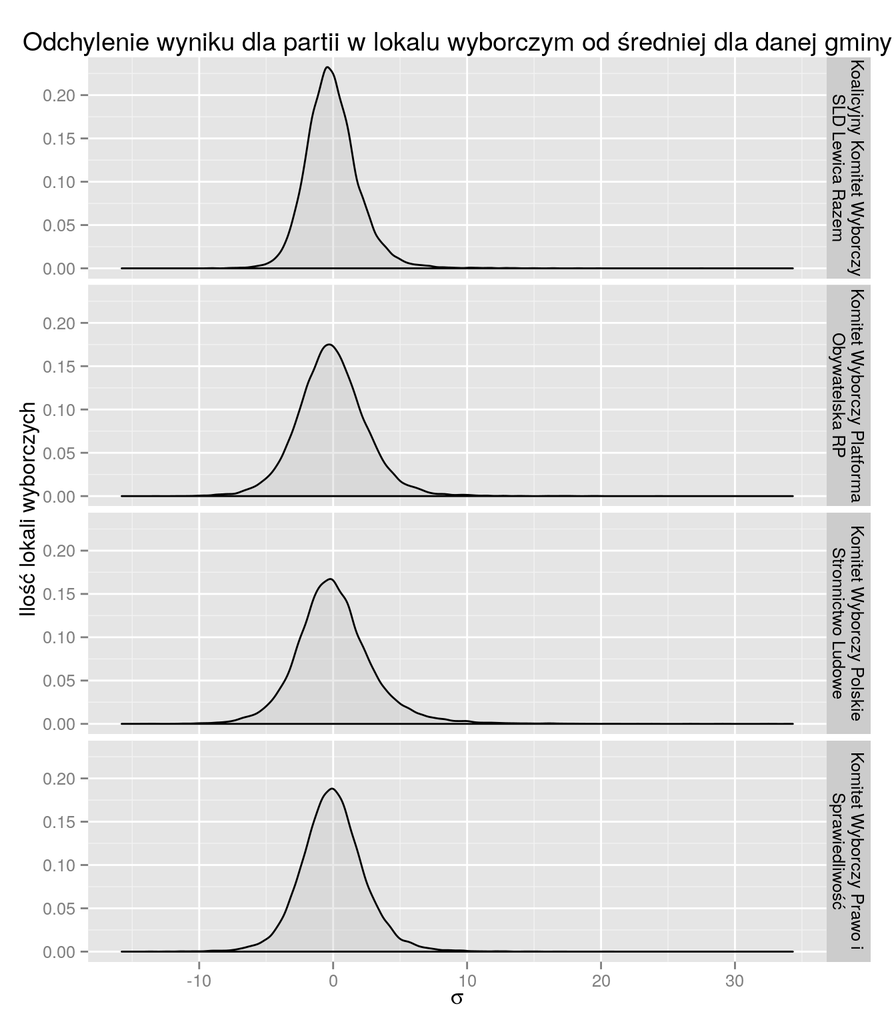

```r
ggplot(dane.diff, aes(x=diff)) +
  geom_density(alpha=.3, kernel="gau", colour="black", fill="gray") +
  facet_grid(partia ~ ., labeller = function(x,y) str_wrap(y,width = 30) ) +
  xlab(expression(sigma)) +
  ylab("Ilość lokali wyborczych") +
  ggtitle("Odchylenie wyniku dla partii w lokalu wyborczym od średniej dla danej gminy")
```

A także w przy uwzględnieniu typów miejscowości.

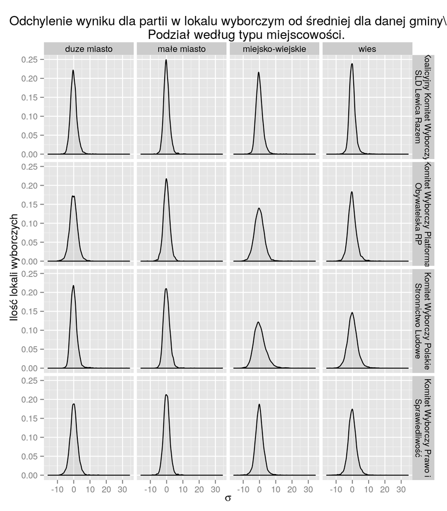

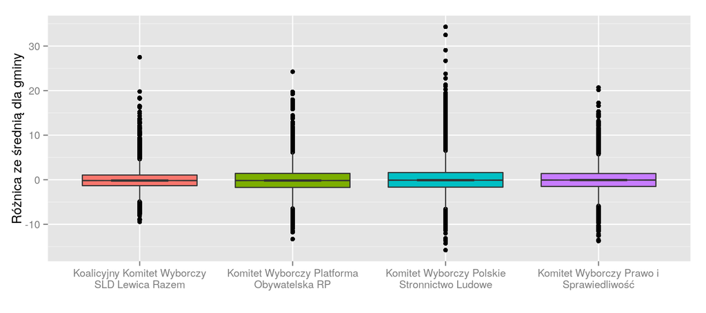

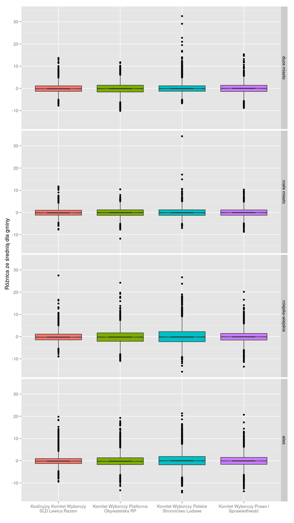

Na wykresach pudełkowych nie wszystko widać. Zróbmy mały test. Z jakimi partiami są związane bardzo ujemne i bardzo dodatnie różnice ze średnią w gminie?

```r
skrajne.duze <- non.zeros(table(dane.diff$partia[dane.diff$diff > diff.kwantyle[["99.0%"]]]))
skrajne.male <- non.zeros(table(dane.diff$partia[dane.diff$diff < diff.kwantyle[["1.0%"]]]))
skrajne.duze
```

```
##
## Koalicyjny Komitet Wyborczy SLD Lewica Razem
##                                          115
##    Komitet Wyborczy Platforma Obywatelska RP
##                                          181
##  Komitet Wyborczy Polskie Stronnictwo Ludowe
##                                          454
##      Komitet Wyborczy Prawo i Sprawiedliwość
##                                          147
```

```r
skrajne.male
```

```
##
## Koalicyjny Komitet Wyborczy SLD Lewica Razem
##                                           41
##    Komitet Wyborczy Platforma Obywatelska RP
##                                          298
##  Komitet Wyborczy Polskie Stronnictwo Ludowe
##                                          343
##      Komitet Wyborczy Prawo i Sprawiedliwość
##                                          215
```

Czy te dwie tabele mogą być takie same?

```r
chisq.test(skrajne.duze, p = skrajne.male, rescale.p = TRUE)
```

```
##
##  Chi-squared test for given probabilities
##
## data:  skrajne.duze
## X-squared = 236.9255, df = 3, p-value < 2.2e-16
```

Jeśli nasze dane rzeczywiście pochodzą z rozkładu standardowego normalnego, to co to oznacza, że wartość jest podejrzana? Mamy 89604 obserwacji, więc wartość musi być bardzo mała

```r
diff.granica <- qnorm(-log(89604/2), log.p = T)
diff.granica
```

```
## [1] -4.082046
```

Możemy patrzeć na zarówno małe i duże

```r
dane.diff %>%
  filter(abs(diff)>abs(diff.granica)) %>%
  group_by(partia) %>%
  summarise(length(diff))
```

```
## Source: local data frame [4 x 2]
##
##                                         partia length(diff)
## 1 Koalicyjny Komitet Wyborczy SLD Lewica Razem          984
## 2    Komitet Wyborczy Platforma Obywatelska RP         2387
## 3  Komitet Wyborczy Polskie Stronnictwo Ludowe         2991
## 4      Komitet Wyborczy Prawo i Sprawiedliwość         1893
```

Jak i po prostu skrajnie duże wyniki, małe prawdopodobne

```r
diff.granica <- qnorm(-log(89604), log.p = T)
dane.diff %>%
  filter(diff>abs(diff.granica)) %>%
  group_by(partia) %>%
  summarise(length(diff))
```

```
## Source: local data frame [4 x 2]
##
##                                         partia length(diff)
## 1 Koalicyjny Komitet Wyborczy SLD Lewica Razem          604
## 2    Komitet Wyborczy Platforma Obywatelska RP         1069
## 3  Komitet Wyborczy Polskie Stronnictwo Ludowe         1660
## 4      Komitet Wyborczy Prawo i Sprawiedliwość          920
```

I rozważmy grupę najbardziej skrajnych, powyżej 10 $\sigma$ od średniej dla gminy.

```r
dane.diff %>%
  filter(diff>10) %>%
  group_by(partia) %>%
  summarise(length(diff))
```

```
## Source: local data frame [4 x 2]
##
##                                         partia length(diff)
## 1 Koalicyjny Komitet Wyborczy SLD Lewica Razem           53
## 2    Komitet Wyborczy Platforma Obywatelska RP           60
## 3  Komitet Wyborczy Polskie Stronnictwo Ludowe          171
## 4      Komitet Wyborczy Prawo i Sprawiedliwość           38
```

Dlaczego tak się dzieje? PSL ma bonus za pierwsze miejsce na liście, dlatego jeśli akurat znalazło sie dużo ludzi, którzy nie potrafili wypełnić karty, to wynik PSL znacznie wzrastał.

W każdym razie, to pokazuje, że coś z wyborami było nie tak. Można zauważyć, że skrajne wyniki dla pozostałych partii co prawda się różnią, ale są w zupełnie innej skali.

Te wyniki dają też wskazówkę, w jakich lokalach wyborczych, warto by szukać nadużyć wyborczych.